# Lecture 22

April 20, 2016

## OkCupid Data

Recall the OkCupid data set of 60K users in SF in 2012. We consider:

| sex | height | has_wine |
| --- | --- | --- |
| female | 67 | TRUE |
| male | 70 | TRUE |
| male | 70 | FALSE |
| male | 65 | FALSE |
| female | 65 | FALSE |

## Height

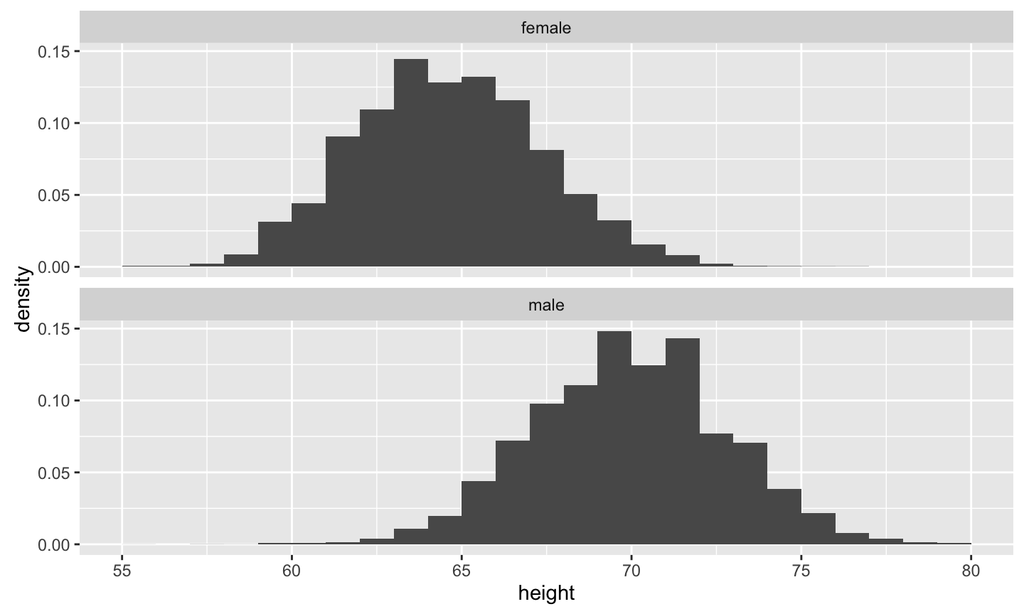

## Wine?

Does the user use the word "wine" in their essay responses?

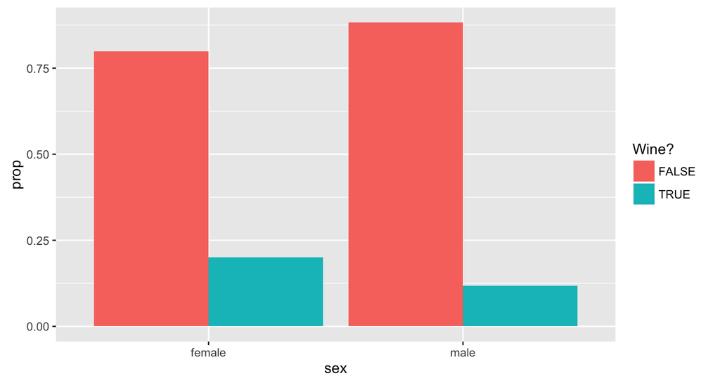

## Predicting Sex

## Logistic Regression

Logistic regression is used your outcome variable \(Y\) is binary, in our case sex.

It models \(\widehat{p}_i\): the fitted probability of being female, given

- their height
- if they used the word "wine"

## Logistic Regression

The model yields \(\widehat{p}_i\)'s, the fitted probability of being female:

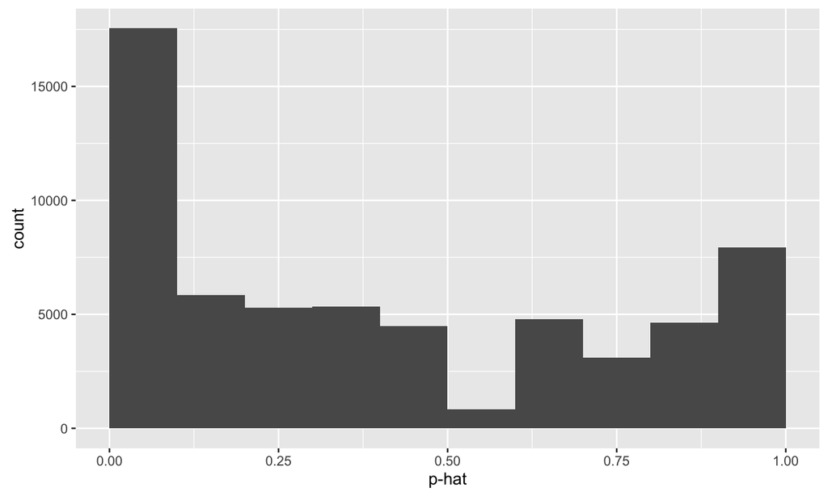

## Decision Threshold

Use 0.9 as the threshold. i.e. declare user \(i\) female if \(\widehat{p}_i>0.9\)

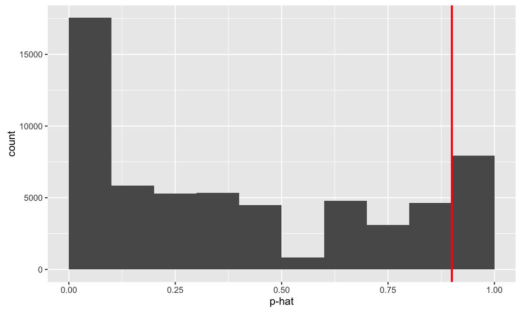

## Decision Threshold

Using 0.9, we obtain the following contingency table of **true sex** and **predicted sex**:

|  | pred_male | pred_female |
| --- | --- | --- |
| true_male | 35453 | 284 |
| true_female | 16434 | 7655 |

## Decision Threshold

We then normalize each row to sum to 1:

|  | pred_male | pred_female |
| --- | --- | --- |
| true_male | 0.992 | 0.008 |
| true_female | 0.682 | 0.318 |

## Decision Threshold

Use 0.1 as the threshold. i.e. declare user \(i\) female if \(\widehat{p}_i>0.1\)

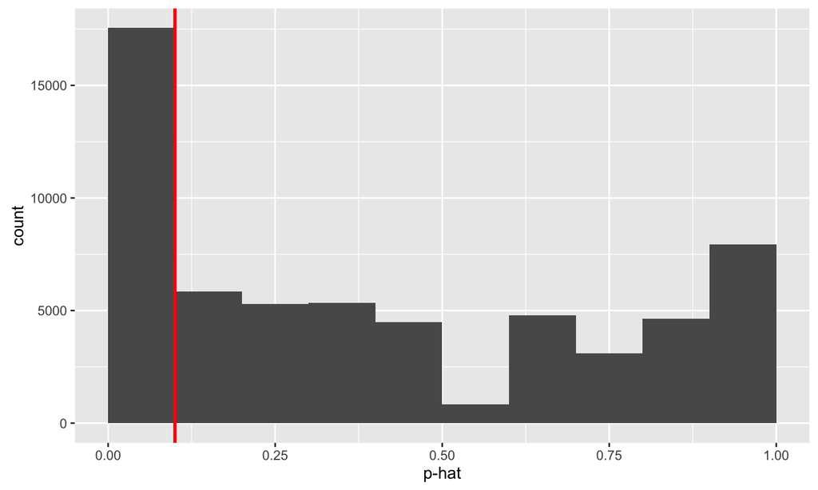

## Decision Threshold

Using 0.1, we obtain the following contingency table of **true sex** and **predicted sex**:

|  | pred_male | pred_female |
| --- | --- | --- |
| true_male | 16960 | 18777 |
| true_female | 587 | 23502 |

## Decision Threshold

We then normalize each row to sum to 1:

|  | pred_male | pred_female |
| --- | --- | --- |
| true_male | 0.475 | 0.525 |
| true_female | 0.024 | 0.976 |

## Moral of the Story

You can't have both:

- Low type I error rate and
- High power

There is a tradeoff. In our case, the threshold allows us to control this tradeoff. In hypothesis testing, it the \(\alpha\)-level you set.

## Simpler Example

Spam filter in email:

- Say you absolutely **want no spam in your inbox**. You need a strict filter, and will probably have non-spam go in your spam box.
- Say you absolutely **don't want to miss any non-spam**, then be prepared to have spam go in your inbox.